# Animal Crossing

tidytuesday

Looking at the unique animal personalities in Animal Crossing.

Ted Laderas  
5/5/2020

# What was your dataset?

Load your dataset in with the function below. The input is the date the dataset was issued. You should be able to get this from the `tt_available()` function.

```r
critic <- readr::read_tsv('https://raw.githubusercontent.com/rfordatascience/tidytuesday/master/data/2020/2020-05-05/critic.tsv')
user_reviews <- readr::read_tsv('https://raw.githubusercontent.com/rfordatascience/tidytuesday/master/data/2020/2020-05-05/user_reviews.tsv')
items <- readr::read_csv('https://raw.githubusercontent.com/rfordatascience/tidytuesday/master/data/2020/2020-05-05/items.csv')
villagers <- readr::read_csv('https://raw.githubusercontent.com/rfordatascience/tidytuesday/master/data/2020/2020-05-05/villagers.csv')
```

# Villagers

```r
skimr::skim(villagers)
```

Table 1: Data summary

| Name | villagers |
| --- | --- |
| Number of rows | 391 |
| Number of columns | 11 |
| _______________________ |  |
| Column type frequency: |  |
| character | 10 |
| numeric | 1 |
| ________________________ |  |
| Group variables | None |

**Variable type: character**

| skim_variable | n_missing | complete_rate | min | max | empty | n_unique | whitespace |
| --- | --- | --- | --- | --- | --- | --- | --- |
| id | 0 | 1.00 | 2 | 8 | 0 | 391 | 0 |
| name | 0 | 1.00 | 2 | 8 | 0 | 391 | 0 |
| gender | 0 | 1.00 | 4 | 6 | 0 | 2 | 0 |
| species | 0 | 1.00 | 3 | 9 | 0 | 35 | 0 |
| birthday | 0 | 1.00 | 3 | 5 | 0 | 361 | 0 |
| personality | 0 | 1.00 | 4 | 6 | 0 | 8 | 0 |
| song | 11 | 0.97 | 7 | 16 | 0 | 92 | 0 |
| phrase | 0 | 1.00 | 2 | 10 | 0 | 388 | 0 |
| full_id | 0 | 1.00 | 11 | 17 | 0 | 391 | 0 |
| url | 0 | 1.00 | 60 | 66 | 0 | 391 | 0 |

**Variable type: numeric**

| skim_variable | n_missing | complete_rate | mean | sd | p0 | p25 | p50 | p75 | p100 | hist |
| --- | --- | --- | --- | --- | --- | --- | --- | --- | --- | --- |
| row_n | 0 | 1 | 239.9 | 140.7 | 2 | 117.5 | 240 | 363.5 | 483 | ▇▇▇▇▇ |

## Personalities by Species

```r
species_count <- villagers %>%
  group_by(species)  %>%
  summarize(species_count = n()) %>%
  arrange(species_count)

datatable(species_count)
```

|  | species | species_count |
| --- | --- | --- |
| 1 | octopus | 3 |
| 2 | cow | 4 |
| 3 | bull | 6 |
| 4 | rhino | 6 |
| 5 | alligator | 7 |
| 6 | anteater | 7 |
| 7 | hippo | 7 |
| 8 | lion | 7 |
| 9 | tiger | 7 |
| 10 | goat | 8 |

[output cut: 25 more lines]

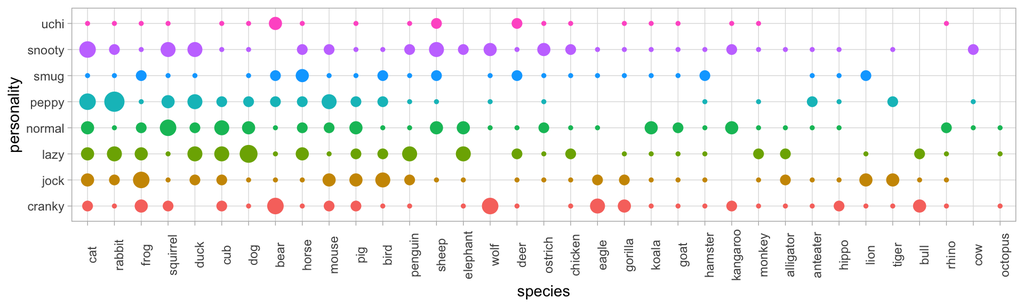

```r
level_order <- villagers %>%
  group_by(species) %>% count() %>%
  arrange(desc(n)) %>%
  pull(species)

villagers %>%
  mutate(species=factor(species, levels=level_order)) %>%
  ggplot() + aes(x=species, y=personality, color=personality) %>%
  geom_count() +
   theme_light() + theme(legend.position = "none") +
  theme(axis.text.x = element_text(angle = 90))
```

[figure not shown]

```r
villagers %>% select(name, species, personality, url) %>%
  mutate(combo = paste(species, personality)) %>% select(name, combo, url) -> villager_index

unique_combos <- villagers %>%
  group_by(species, personality) %>% summarize(n=n()) %>%
  filter(n == 1) %>% mutate(combo=paste(species, personality)) %>%
  inner_join(y=villager_index, by=c("combo")) %>% ungroup()

out_image <- unique_combos %>%
  ggplot() + aes(x=species, y=personality, image=url, name=name) +
  geom_count() +
  geom_raster(fill="white", color="black") +
  geom_image(asp=1.2, size=0.03) +
   theme_minimal() + theme(legend.position = "none") +
  theme(axis.text.x = element_text(angle = 90)) + labs(title="There can be only one", subtitle = "Unique Personality/Species combos in Animal Crossing")

out_image
```

```r
ggsave(plot=out_image, filename = "unique_animal_personalities.pdf", width=10, height = 5)
```

```r
pers_vil <- villagers %>%
  group_by(personality, species) %>%
  summarize(count=n()) %>%
  #filter(count==1) %>%
  arrange(species)

pers_vil %>%
  arrange(desc(count)) %>%
  datatable()
```

|  | personality | species | count |
| --- | --- | --- | --- |
| 1 | peppy | rabbit | 8 |
| 2 | lazy | dog | 6 |
| 3 | cranky | bear | 5 |
| 4 | peppy | cat | 5 |
| 5 | snooty | cat | 5 |
| 6 | jock | frog | 5 |
| 7 | normal | squirrel | 5 |
| 8 | cranky | wolf | 5 |
| 9 | jock | bird | 4 |
| 10 | lazy | cub | 4 |

[output cut: 207 more lines]

# Items

```r
skimr::skim(items)
```

Table 2: Data summary

| Name | items |
| --- | --- |
| Number of rows | 4565 |
| Number of columns | 16 |
| _______________________ |  |
| Column type frequency: |  |
| character | 10 |
| logical | 2 |
| numeric | 4 |
| ________________________ |  |
| Group variables | None |

**Variable type: character**

| skim_variable | n_missing | complete_rate | min | max | empty | n_unique | whitespace |
| --- | --- | --- | --- | --- | --- | --- | --- |
| id | 0 | 1.00 | 3 | 29 | 0 | 4200 | 0 |
| name | 0 | 1.00 | 3 | 29 | 0 | 4200 | 0 |
| category | 0 | 1.00 | 4 | 11 | 0 | 21 | 0 |
| sell_currency | 36 | 0.99 | 5 | 5 | 0 | 1 | 0 |
| buy_currency | 1014 | 0.78 | 5 | 5 | 0 | 2 | 0 |
| sources | 3663 | 0.20 | 3 | 71 | 0 | 125 | 0 |
| recipe_id | 3977 | 0.13 | 4 | 20 | 0 | 102 | 0 |
| games_id | 0 | 1.00 | 2 | 2 | 0 | 1 | 0 |
| id_full | 1528 | 0.67 | 8 | 34 | 0 | 2704 | 0 |
| image_url | 1528 | 0.67 | 56 | 82 | 0 | 2672 | 0 |

**Variable type: logical**

| skim_variable | n_missing | complete_rate | mean | count |
| --- | --- | --- | --- | --- |
| orderable | 2775 | 0.39 | 0.45 | FAL: 976, TRU: 814 |
| customizable | 3992 | 0.13 | 0.45 | FAL: 316, TRU: 257 |

**Variable type: numeric**

| skim_variable | n_missing | complete_rate | mean | sd | p0 | p25 | p50 | p75 | p100 | hist |
| --- | --- | --- | --- | --- | --- | --- | --- | --- | --- | --- |
| num_id | 0 | 1.00 | 3661.62 | 2187.95 | 12 | 1722 | 3569 | 5607 | 7443 | ▇▇▇▇▇ |
| sell_value | 36 | 0.99 | 2261.38 | 11313.23 | 5 | 240 | 390 | 1000 | 300000 | ▇▁▁▁▁ |
| buy_value | 1014 | 0.78 | 6959.65 | 34326.09 | 40 | 870 | 1300 | 2700 | 1200000 | ▇▁▁▁▁ |
| recipe | 3977 | 0.13 | 4.71 | 6.49 | 1 | 2 | 3 | 6 | 90 | ▇▁▁▁▁ |

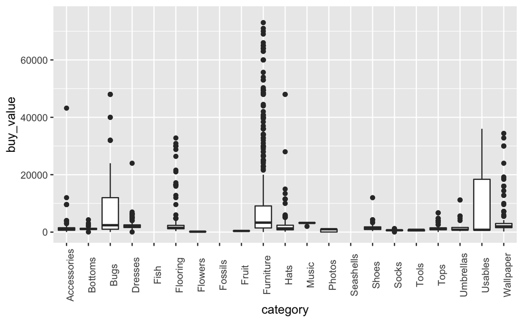

```r
library(tidyverse)
items %>% ggplot() +
  aes(x=category, y=buy_value) +
  geom_boxplot() +
  ylim(c(0,75000)) +
  theme(axis.text.x  = element_text(angle = 90))
```

# Most Expensive Items

This was the original code in my tweet:

```r
library(gt)

 items %>%
  top_n(10, buy_value) %>%
  arrange(desc(buy_value)) %>%
  select(name, sell_value, buy_value, category, image=image_url) %>%
  gt() %>%
   text_transform(
    locations = cells_body(vars(image)),
    fn = function(x) {
      web_image(
        url = x,
        height = 50
      )
    }
  )
```

name

sell_value

buy_value

category

image

Royal Crown

300000

1200000

Hats

Crown

250000

1000000

Hats

Gold Armor

80000

320000

Dresses

[figure not shown]

Golden Casket

80000

320000

Furniture

Grand Piano

65000

260000

Furniture

Golden Toilet

60000

240000

Furniture

Blue Steel Staircase

NA

228000

Furniture

[figure not shown]

Iron Bridge

NA

228000

Furniture

[figure not shown]

Red Steel Staircase

NA

228000

Furniture

[figure not shown]

Red Zen Bridge

NA

228000

Furniture

[figure not shown]

Zen Bridge

NA

228000

Furniture

[figure not shown]

Here’s a function.

```r
most_expensive <- function(category_name=NULL, price_category=buy_value){

  if(!is.null(category_name)){
    items <- items %>%
      filter(category == category_name)
  }

  items %>%
  top_n(10, {{price_category}}) %>%
  arrange(desc({{price_category}})) %>%
  select(name, sell_value, buy_value, category, image=image_url) %>%
  gt() %>%
   text_transform(
    locations = cells_body(vars(image)),
    fn = function(x) {
      web_image(
        url = x,
        height = 50
      )
    }
  )

}
```

# Reproducing the above table

```r
most_expensive()
```

name

sell_value

buy_value

category

image

Royal Crown

300000

1200000

Hats

Crown

250000

1000000

Hats

Gold Armor

80000

320000

Dresses

[figure not shown]

Golden Casket

80000

320000

Furniture

Grand Piano

65000

260000

Furniture

Golden Toilet

60000

240000

Furniture

Blue Steel Staircase

NA

228000

Furniture

[figure not shown]

Iron Bridge

NA

228000

Furniture

[figure not shown]

Red Steel Staircase

NA

228000

Furniture

[figure not shown]

Red Zen Bridge

NA

228000

Furniture

[figure not shown]

Zen Bridge

NA

228000

Furniture

[figure not shown]

# Most Expensive Furniture

```r
most_expensive("Furniture")
```

| name | sell_value | buy_value | category | image |
| --- | --- | --- | --- | --- |
| Golden Casket | 80000 | 320000 | Furniture |  |
| Grand Piano | 65000 | 260000 | Furniture |  |
| Golden Toilet | 60000 | 240000 | Furniture |  |
| Blue Steel Staircase | NA | 228000 | Furniture |  |
| Iron Bridge | NA | 228000 | Furniture |  |
| Red Steel Staircase | NA | 228000 | Furniture |  |
| Red Zen Bridge | NA | 228000 | Furniture |  |
| Zen Bridge | NA | 228000 | Furniture |  |
| Elaborate Kimono Stand | 55000 | 220000 | Furniture |  |
| Golden Seat | 50000 | 200000 | Furniture |  |

# Most Expensive Hats

```r
library(gt)
most_expensive("Hats")
```

name

sell_value

buy_value

category

image

Royal Crown

300000

1200000

Hats

Crown

250000

1000000

Hats

Gold Helmet

50000

200000

Hats

[figure not shown]

Blue Rose Crown

12000

48000

Hats

[figure not shown]

Gold Rose Crown

12000

48000

Hats

[figure not shown]

Snowperson Head

7000

28000

Hats

[figure not shown]

Knight's Helmet

3750

15000

Hats

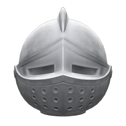

Dark Cosmos Crown

3360

13440

Hats

[figure not shown]

Chic Rose Crown

2880

11520

Hats

[figure not shown]

Purple Hyacinth Crown

2880

11520

Hats

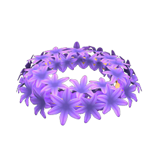

Purple Pansy Crown

2880

11520

Hats

[figure not shown]

Purple Windflower Crown

2880

11520

Hats

[figure not shown]

Simple Mum Crown

2880

11520

Hats

[figure not shown]

# Most Expensive Fossils

```r
most_expensive("Fossils", sell_value)
```

| name | sell_value | buy_value | category | image |
| --- | --- | --- | --- | --- |
| Brachio Skull | 6000 | NA | Fossils |  |
| T. Rex Skull | 6000 | NA | Fossils |  |
| Brachio Chest | 5500 | NA | Fossils |  |
| Brachio Tail | 5500 | NA | Fossils |  |
| Dimetrodon Skull | 5500 | NA | Fossils |  |
| Right Megalo Side | 5500 | NA | Fossils |  |
| T. Rex Torso | 5500 | NA | Fossils |  |
| Tricera Skull | 5500 | NA | Fossils |  |
| Brachio Pelvis | 5000 | NA | Fossils |  |
| Dimetrodon Torso | 5000 | NA | Fossils |  |
| Diplo Skull | 5000 | NA | Fossils |  |
| Diplo Tail | 5000 | NA | Fossils |  |
| Left Quetzal Wing | 5000 | NA | Fossils |  |
| Right Quetzal Wing | 5000 | NA | Fossils |  |
| Stego Skull | 5000 | NA | Fossils |  |
| T. Rex Tail | 5000 | NA | Fossils |  |
| Tricera Torso | 5000 | NA | Fossils |  |

# Priceless Items by Category

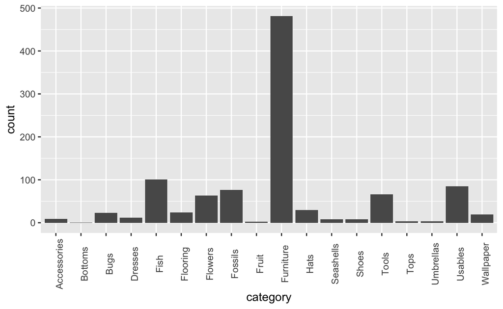

```r
items %>%
  filter(is.na(buy_value)) %>%
  ggplot(aes(x=category)) + geom_bar() +
  theme(axis.text.x = element_text(angle=90))
```

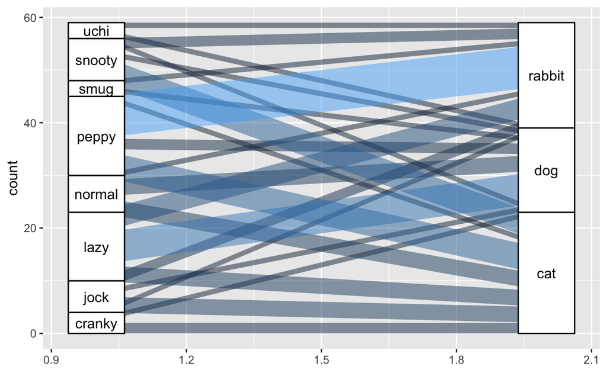

```r
library(ggalluvial)

pers_vil %>% filter(species %in% c("cat", "rabbit", "dog")) %>%
ggplot(
       aes(y = count,
           axis1 = personality, axis2 = species)) +
           geom_alluvium(aes(fill = count),
                width = 0, knot.pos = 0, reverse = FALSE) +
  guides(fill = FALSE) +
  geom_stratum(width = 1/8, reverse = FALSE) +
    geom_text(stat = "stratum", infer.label = TRUE, reverse = FALSE)
```